# Final Project COVID-19

Molly Robertson

4/12/2020

# Final Project COVID-19

```r
#Load In Necessary Packages
library(DataComputing)
library(tidyr)
```

### Loading In Data

```r
#Rename Data Tables
GlobalRecovered <- read.csv("https://data.humdata.org/hxlproxy/data/download/time_series_covid19_recovered_global_iso3_regions.csv?dest=data_edit&filter01=merge&merge-url01=https%3A%2F%2Fdocs.google.com%2Fspreadsheets%2Fd%2Fe%2F2PACX-1vTglKQRXpkKSErDiWG6ycqEth32MY0reMuVGhaslImLjfuLU0EUgyyu2e-3vKDArjqGX7dXEBV8FJ4f%2Fpub%3Fgid%3D1326629740%26single%3Dtrue%26output%3Dcsv&merge-keys01=%23country%2Bname&merge-tags01=%23country%2Bcode%2C%23region%2Bmain%2Bcode%2C%23region%2Bmain%2Bname%2C%23region%2Bsub%2Bcode%2C%23region%2Bsub%2Bname%2C%23region%2Bintermediate%2Bcode%2C%23region%2Bintermediate%2Bname&filter02=merge&merge-url02=https%3A%2F%2Fdocs.google.com%2Fspreadsheets%2Fd%2Fe%2F2PACX-1vTglKQRXpkKSErDiWG6ycqEth32MY0reMuVGhaslImLjfuLU0EUgyyu2e-3vKDArjqGX7dXEBV8FJ4f%2Fpub%3Fgid%3D398158223%26single%3Dtrue%26output%3Dcsv&merge-keys02=%23adm1%2Bname&merge-tags02=%23country%2Bcode%2C%23region%2Bmain%2Bcode%2C%23region%2Bmain%2Bname%2C%23region%2Bsub%2Bcode%2C%23region%2Bsub%2Bname%2C%23region%2Bintermediate%2Bcode%2C%23region%2Bintermediate%2Bname&merge-replace02=on&merge-overwrite02=on&tagger-match-all=on&tagger-01-header=province%2Fstate&tagger-01-tag=%23adm1%2Bname&tagger-02-header=country%2Fregion&tagger-02-tag=%23country%2Bname&tagger-03-header=lat&tagger-03-tag=%23geo%2Blat&tagger-04-header=long&tagger-04-tag=%23geo%2Blon&header-row=1&url=https%3A%2F%2Fraw.githubusercontent.com%2FCSSEGISandData%2FCOVID-19%2Fmaster%2Fcsse_covid_19_data%2Fcsse_covid_19_time_series%2Ftime_series_covid19_recovered_global.csv")
GlobalDeaths<- read.csv("https://data.humdata.org/hxlproxy/data/download/time_series_covid19_deaths_global_iso3_regions.csv?dest=data_edit&filter01=merge&merge-url01=https%3A%2F%2Fdocs.google.com%2Fspreadsheets%2Fd%2Fe%2F2PACX-1vTglKQRXpkKSErDiWG6ycqEth32MY0reMuVGhaslImLjfuLU0EUgyyu2e-3vKDArjqGX7dXEBV8FJ4f%2Fpub%3Fgid%3D1326629740%26single%3Dtrue%26output%3Dcsv&merge-keys01=%23country%2Bname&merge-tags01=%23country%2Bcode%2C%23region%2Bmain%2Bcode%2C%23region%2Bmain%2Bname%2C%23region%2Bsub%2Bcode%2C%23region%2Bsub%2Bname%2C%23region%2Bintermediate%2Bcode%2C%23region%2Bintermediate%2Bname&filter02=merge&merge-url02=https%3A%2F%2Fdocs.google.com%2Fspreadsheets%2Fd%2Fe%2F2PACX-1vTglKQRXpkKSErDiWG6ycqEth32MY0reMuVGhaslImLjfuLU0EUgyyu2e-3vKDArjqGX7dXEBV8FJ4f%2Fpub%3Fgid%3D398158223%26single%3Dtrue%26output%3Dcsv&merge-keys02=%23adm1%2Bname&merge-tags02=%23country%2Bcode%2C%23region%2Bmain%2Bcode%2C%23region%2Bmain%2Bname%2C%23region%2Bsub%2Bcode%2C%23region%2Bsub%2Bname%2C%23region%2Bintermediate%2Bcode%2C%23region%2Bintermediate%2Bname&merge-replace02=on&merge-overwrite02=on&tagger-match-all=on&tagger-01-header=province%2Fstate&tagger-01-tag=%23adm1%2Bname&tagger-02-header=country%2Fregion&tagger-02-tag=%23country%2Bname&tagger-03-header=lat&tagger-03-tag=%23geo%2Blat&tagger-04-header=long&tagger-04-tag=%23geo%2Blon&header-row=1&url=https%3A%2F%2Fraw.githubusercontent.com%2FCSSEGISandData%2FCOVID-19%2Fmaster%2Fcsse_covid_19_data%2Fcsse_covid_19_time_series%2Ftime_series_covid19_deaths_global.csv")
GlobalConfirmed <- read.csv("https://data.humdata.org/hxlproxy/data/download/time_series_covid19_confirmed_global_iso3_regions.csv?dest=data_edit&filter01=merge&merge-url01=https%3A%2F%2Fdocs.google.com%2Fspreadsheets%2Fd%2Fe%2F2PACX-1vTglKQRXpkKSErDiWG6ycqEth32MY0reMuVGhaslImLjfuLU0EUgyyu2e-3vKDArjqGX7dXEBV8FJ4f%2Fpub%3Fgid%3D1326629740%26single%3Dtrue%26output%3Dcsv&merge-keys01=%23country%2Bname&merge-tags01=%23country%2Bcode%2C%23region%2Bmain%2Bcode%2C%23region%2Bmain%2Bname%2C%23region%2Bsub%2Bcode%2C%23region%2Bsub%2Bname%2C%23region%2Bintermediate%2Bcode%2C%23region%2Bintermediate%2Bname&filter02=merge&merge-url02=https%3A%2F%2Fdocs.google.com%2Fspreadsheets%2Fd%2Fe%2F2PACX-1vTglKQRXpkKSErDiWG6ycqEth32MY0reMuVGhaslImLjfuLU0EUgyyu2e-3vKDArjqGX7dXEBV8FJ4f%2Fpub%3Fgid%3D398158223%26single%3Dtrue%26output%3Dcsv&merge-keys02=%23adm1%2Bname&merge-tags02=%23country%2Bcode%2C%23region%2Bmain%2Bcode%2C%23region%2Bmain%2Bname%2C%23region%2Bsub%2Bcode%2C%23region%2Bsub%2Bname%2C%23region%2Bintermediate%2Bcode%2C%23region%2Bintermediate%2Bname&merge-replace02=on&merge-overwrite02=on&tagger-match-all=on&tagger-01-header=province%2Fstate&tagger-01-tag=%23adm1%2Bname&tagger-02-header=country%2Fregion&tagger-02-tag=%23country%2Bname&tagger-03-header=lat&tagger-03-tag=%23geo%2Blat&tagger-04-header=long&tagger-04-tag=%23geo%2Blon&header-row=1&url=https%3A%2F%2Fraw.githubusercontent.com%2FCSSEGISandData%2FCOVID-19%2Fmaster%2Fcsse_covid_19_data%2Fcsse_covid_19_time_series%2Ftime_series_covid19_confirmed_global.csv")
```

### Looking at Grand Totals by Worldwide Region

At the most basic level, I wanted to look at the total confirmed cases, deaths, and recovered based on regions. The regions in the dataset are Africa, Americas, Asia, Europe and Oceania. First, is the table and graph for confirmed cases, followed by deaths and then recovered.

```r
GlobalConfirmed1<-
GlobalConfirmed%>%
  group_by(Region.Name)%>%
  summarise(totalconfirmed = sum((X4.11.20)))
GlobalConfirmed1<-
 GlobalConfirmed1[-2,]
GlobalConfirmed1<-
  GlobalConfirmed1[-1,]
head(GlobalConfirmed1)
```

```
## # A tibble: 5 x 2
##   Region.Name totalconfirmed
##   <fct>                <int>
## 1 Africa               14215
## 2 Americas            610215
## 3 Asia                286456
## 4 Europe              816703
## 5 Oceania               7702
```

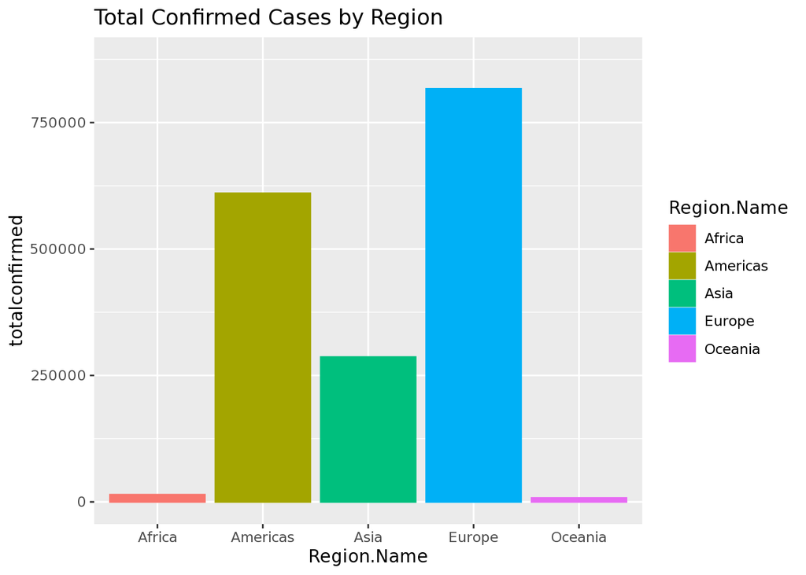

```r
GlobalConfirmed1%>%
  ggplot(aes(x=Region.Name, y=totalconfirmed)) +
  geom_bar(stat = "identity",aes(color=Region.Name, fill=Region.Name)) +
  ggtitle("Total Confirmed Cases by Region") +
  ylim(0, 875000)
```

Looking at the graph above, it appears as though Europe has the most cases with the Americas behind. These graphs need to be further divided to get the entire picture, as the majority of cases in the Americas are in the United States. Certain regions are dominated by certains countries.

```r
GlobalDeaths1<-
GlobalDeaths%>%
  group_by(Region.Name)%>%
  summarise(Total_Deaths = sum((X4.11.20)))
GlobalDeaths1<-
 GlobalDeaths1[-2,] #get rid of useless row
GlobalDeaths1<-
  GlobalDeaths1[-1,] #get rid of useless row
head(GlobalDeaths1)
```

```
## # A tibble: 5 x 2
##   Region.Name Total_Deaths
##   <fct>              <int>
## 1 Africa               745
## 2 Americas           27517
## 3 Asia               10588
## 4 Europe             73497
## 5 Oceania               61
```

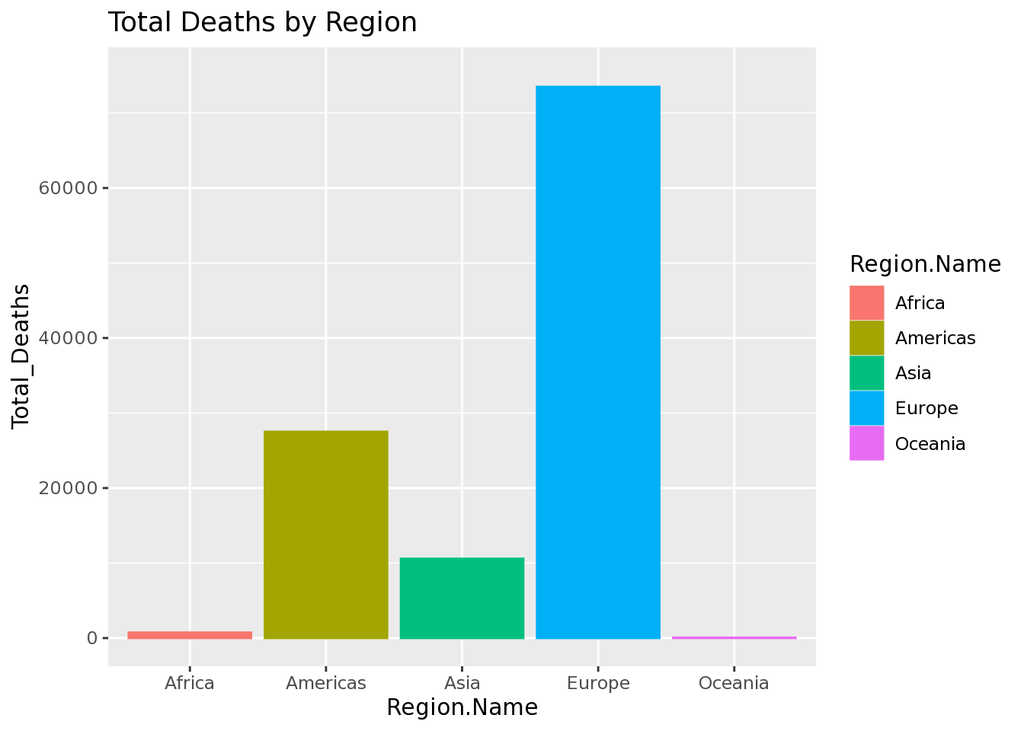

```r
GlobalDeaths1%>%
  ggplot(aes(x=Region.Name, y=Total_Deaths)) +
  geom_bar(stat = "identity",aes(color=Region.Name, fill=Region.Name)) +
  ggtitle("Total Deaths by Region") +
  ylim(0, 75000)
```

Unfortunately, Europe has the highest total number of deaths as well. It must be noted that many European countries are a few weeks ahead of the outbreak in the Americas, specifically the United States so this can change. These graphs also do not take into account total proportion of a population that have been infected, these are just pure counts.

```r
GlobalRecovered1<-
GlobalRecovered%>%
  group_by(Region.Name)%>%
  summarise(Total_Recovered = sum((X4.11.20)))
GlobalRecovered1<-
 GlobalRecovered1[-2,]
GlobalRecovered1<-
  GlobalRecovered1[-1,]
head(GlobalRecovered1)
```

```
## # A tibble: 5 x 2
##   Region.Name Total_Recovered
##   <fct>                 <int>
## 1 Africa                 2457
## 2 Americas              44274
## 3 Asia                 142464
## 4 Europe               210067
## 5 Oceania                2229
```

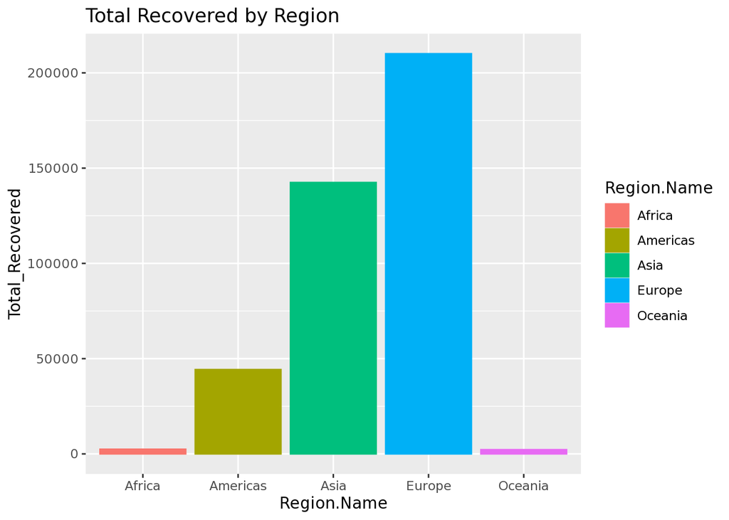

```r
GlobalRecovered1%>%
  ggplot(aes(x=Region.Name, y=Total_Recovered)) +
  geom_bar(stat = "identity",aes(color=Region.Name, fill=Region.Name)) +
  ggtitle("Total Recovered by Region")
```

Upliftingly, Europe does also have the highest amount of total recovered. Sadly, the Americas is still low on the recovered as we are nearing the peak of the outbreak in the United States. If the data we currently have is correct, the Asia region was able to contain their outbreak, mostly China, and keep deaths relatively low with recoveries high.

These graphs are fairly basic, and do not give us great insight into the outbreak. To further investigate this pandemic, it is necessary to look at a few countries from each of the regions, and their specific plan to combat the spread of the coronavirus.

### Data Wrangling: Separating the Totals by Country

First, I filtered the data tables so that only the name of the country and the confirmed cases for each date were included.

```r
GlobalConfirmedWide<-
 GlobalConfirmed[,-c(1,3,4,86,87,88,89,90,91,92)] #keeps only country and dates
head(GlobalConfirmedWide)
```

```
##   Country.Region X1.22.20 X1.23.20 X1.24.20 X1.25.20 X1.26.20 X1.27.20
## 1  #country+name       NA       NA       NA       NA       NA       NA
## 2    Afghanistan        0        0        0        0        0        0
## 3        Albania        0        0        0        0        0        0
## 4        Algeria        0        0        0        0        0        0
## 5        Andorra        0        0        0        0        0        0
## 6         Angola        0        0        0        0        0        0
##   X1.28.20 X1.29.20 X1.30.20 X1.31.20 X2.1.20 X2.2.20 X2.3.20 X2.4.20
## 1       NA       NA       NA       NA      NA      NA      NA      NA
## 2        0        0        0        0       0       0       0       0
## 3        0        0        0        0       0       0       0       0
## 4        0        0        0        0       0       0       0       0
## 5        0        0        0        0       0       0       0       0
## 6        0        0        0        0       0       0       0       0
##   X2.5.20 X2.6.20 X2.7.20 X2.8.20 X2.9.20 X2.10.20 X2.11.20 X2.12.20
```

[output cut: 83 more lines]

Afterwards, I combined the same countries together so that each case represented one country completley.

```r
GlobalConfirmedWide1<-
GlobalConfirmedWide%>%
  group_by(Country.Region)%>%
  summarise(S1.22.20 =sum(X1.22.20), S1.23.20 =sum(X1.23.20), S1.24.20 =sum(X1.24.20), S1.25.20 =sum(X1.25.20), S1.26.20 =sum(X1.26.20), S1.27.20 =sum(X1.27.20), S1.28.20 =sum(X1.28.20), S1.29.20 =sum(X1.29.20), S1.30.20 =sum(X1.30.20), S1.31.20 =sum(X1.31.20), S2.1.20 =sum(X2.1.20), S2.2.20 =sum(X2.2.20), S2.3.20 =sum(X2.3.20), S2.4.20 =sum(X2.4.20), S2.5.20 =sum(X2.5.20), S2.6.20 =sum(X2.6.20), S2.7.20 =sum(X2.7.20), S2.8.20 =sum(X2.8.20), S2.9.20 =sum(X2.9.20), S2.10.20 =sum(X2.10.20), S2.11.20 =sum(X2.11.20), S2.12.20 =sum(X2.12.20), S2.13.20 =sum(X2.13.20), S2.14.20 =sum(X2.14.20), S2.15.20 =sum(X2.15.20), S2.16.20 =sum(X2.16.20), S2.17.20 =sum(X2.17.20), S2.18.20 =sum(X2.18.20), S2.19.20 =sum(X2.19.20), S2.20.20 =sum(X2.20.20), S2.21.20 =sum(X2.21.20), S2.22.20 =sum(X2.22.20), S2.23.20 =sum(X2.23.20), S2.24.20 =sum(X2.24.20), S2.25.20 =sum(X2.25.20), S2.26.20 =sum(X2.26.20), S2.27.20 =sum(X2.27.20), S2.28.20 =sum(X2.28.20), S2.29.20 =sum(X2.29.20), S3.1.20 =sum(X3.1.20), S3.2.20 =sum(X3.2.20), S3.3.20 =sum(X3.3.20), S3.4.20 =sum(X3.4.20), S3.5.20 =sum(X3.5.20), S3.6.20 =sum(X3.6.20), S3.7.20 =sum(X3.7.20), S3.8.20 =sum(X3.8.20), S3.9.20 =sum(X3.9.20), S3.10.20 =sum(X3.10.20), S3.11.20 =sum(X3.11.20), S3.12.20 =sum(X3.12.20), S3.13.20 =sum(X3.13.20), S3.14.20 =sum(X3.14.20), S3.15.20 =sum(X3.15.20), S3.16.20 =sum(X3.16.20), S3.17.20 =sum(X3.18.20), S3.19.20 =sum(X3.19.20), S3.20.20 =sum(X3.20.20), S3.21.20 =sum(X3.21.20), S3.22.20 =sum(X3.22.20), S3.23.20 =sum(X3.23.20), S3.24.20 =sum(X3.24.20), S3.25.20 =sum(X3.25.20), S3.26.20 =sum(X3.26.20), S3.27.20 =sum(X3.27.20), S3.28.20 =sum(X3.28.20), S3.29.20 =sum(X3.29.20), S3.30.20 =sum(X3.30.20), S3.31.20 =sum(X3.31.20), S4.1.20 =sum(X4.1.20), S4.2.20 =sum(X4.2.20), S4.3.20 =sum(X4.3.20), S4.4.20 =sum(X4.4.20), S4.5.20 =sum(X4.5.20), S4.6.20 =sum(X4.6.20), S4.7.20 =sum(X4.7.20), S4.8.20 =sum(X4.8.20), S4.9.20 =sum(X4.9.20), S4.10.20 =sum(X4.10.20), S4.11.20 =sum(X4.11.20)) #to combine countries together that had various cases per province
```

Next, I wanted the dates as the cases and the countries as the variables, so I transposed the data table.

```r
GlobalConfirmedWide2<-
  t(GlobalConfirmedWide1)
GlobalConfirmedWide2<-
  GlobalConfirmedWide2[,-1] #removes blank first column


colnames(GlobalConfirmedWide2) = GlobalConfirmedWide2[1,]
GlobalConfirmedWide2 = GlobalConfirmedWide2[-1, ] #to make the countries the variable names

GlobalConfirmedWide2<-as.data.frame(GlobalConfirmedWide2) #to convert from matrix to data frame
head(GlobalConfirmedWide2)  #only showing output for this first one because they are long
```

```
##          Afghanistan Albania Algeria Andorra Angola Antigua and Barbuda
## S1.22.20           0       0       0       0      0                   0
## S1.23.20           0       0       0       0      0                   0
## S1.24.20           0       0       0       0      0                   0
## S1.25.20           0       0       0       0      0                   0
## S1.26.20           0       0       0       0      0                   0
## S1.27.20           0       0       0       0      0                   0
##          Argentina Armenia Australia Austria Azerbaijan Bahamas Bahrain
## S1.22.20         0       0         0       0          0       0       0
## S1.23.20         0       0         0       0          0       0       0
## S1.24.20         0       0         0       0          0       0       0
## S1.25.20         0       0         0       0          0       0       0
## S1.26.20         0       0         4       0          0       0       0
## S1.27.20         0       0         5       0          0       0       0
##          Bangladesh Barbados Belarus Belgium Belize Benin Bhutan Bolivia
## S1.22.20          0        0       0       0      0     0      0       0
## S1.23.20          0        0       0       0      0     0      0       0
## S1.24.20          0        0       0       0      0     0      0       0
## S1.25.20          0        0       0       0      0     0      0       0
## S1.26.20          0        0       0       0      0     0      0       0
## S1.27.20          0        0       0       0      0     0      0       0
##          Bosnia and Herzegovina Botswana Brazil Brunei Bulgaria
## S1.22.20                      0        0      0      0        0
## S1.23.20                      0        0      0      0        0
## S1.24.20                      0        0      0      0        0
## S1.25.20                      0        0      0      0        0
## S1.26.20                      0        0      0      0        0
## S1.27.20                      0        0      0      0        0
##          Burkina Faso Burma Burundi Cabo Verde Cambodia Cameroon Canada
## S1.22.20            0     0       0          0        0        0      0
## S1.23.20            0     0       0          0        0        0      0
## S1.24.20            0     0       0          0        0        0      0
## S1.25.20            0     0       0          0        0        0      0
## S1.26.20            0     0       0          0        0        0      1
## S1.27.20            0     0       0          0        1        0      1
##          Central African Republic Chad Chile China Colombia
## S1.22.20                        0    0     0   548        0
## S1.23.20                        0    0     0   643        0
## S1.24.20                        0    0     0   920        0
## S1.25.20                        0    0     0  1406        0
```

[output cut: 155 more lines]

```
## S1.27.20      0      0       0                    0              0       0
##            US Uzbekistan Venezuela Vietnam West Bank and Gaza
## S1.22.20    1          0         0       0                  0
## S1.23.20    1          0         0       2                  0
## S1.24.20    2          0         0       2                  0
## S1.25.20    2          0         0       2                  0
## S1.26.20    5          0         0       2                  0
## S1.27.20    5          0         0       2                  0
##          Western Sahara Yemen Zambia Zimbabwe
## S1.22.20              0     0      0        0
## S1.23.20              0     0      0        0
## S1.24.20              0     0      0        0
## S1.25.20              0     0      0        0
## S1.26.20              0     0      0        0
## S1.27.20              0     0      0        0
```

Now, I can use this data to create graphs that show changes in confirmed cases per country over time.

Afterwards, this same process was repeated for deaths.

```r
GlobalDeathsWide<-
  GlobalDeaths[,-c(1,3,4,86,87,88,89,90,91,92)] #keeps only country region and dates
```

```r
GlobalDeathsWide1<-
GlobalDeathsWide%>%
  group_by(Country.Region)%>%
  summarise(S1.22.20 =sum(X1.22.20), S1.23.20 =sum(X1.23.20), S1.24.20 =sum(X1.24.20), S1.25.20 =sum(X1.25.20), S1.26.20 =sum(X1.26.20), S1.27.20 =sum(X1.27.20), S1.28.20 =sum(X1.28.20), S1.29.20 =sum(X1.29.20), S1.30.20 =sum(X1.30.20), S1.31.20 =sum(X1.31.20), S2.1.20 =sum(X2.1.20), S2.2.20 =sum(X2.2.20), S2.3.20 =sum(X2.3.20), S2.4.20 =sum(X2.4.20), S2.5.20 =sum(X2.5.20), S2.6.20 =sum(X2.6.20), S2.7.20 =sum(X2.7.20), S2.8.20 =sum(X2.8.20), S2.9.20 =sum(X2.9.20), S2.10.20 =sum(X2.10.20), S2.11.20 =sum(X2.11.20), S2.12.20 =sum(X2.12.20), S2.13.20 =sum(X2.13.20), S2.14.20 =sum(X2.14.20), S2.15.20 =sum(X2.15.20), S2.16.20 =sum(X2.16.20), S2.17.20 =sum(X2.17.20), S2.18.20 =sum(X2.18.20), S2.19.20 =sum(X2.19.20), S2.20.20 =sum(X2.20.20), S2.21.20 =sum(X2.21.20), S2.22.20 =sum(X2.22.20), S2.23.20 =sum(X2.23.20), S2.24.20 =sum(X2.24.20), S2.25.20 =sum(X2.25.20), S2.26.20 =sum(X2.26.20), S2.27.20 =sum(X2.27.20), S2.28.20 =sum(X2.28.20), S2.29.20 =sum(X2.29.20), S3.1.20 =sum(X3.1.20), S3.2.20 =sum(X3.2.20), S3.3.20 =sum(X3.3.20), S3.4.20 =sum(X3.4.20), S3.5.20 =sum(X3.5.20), S3.6.20 =sum(X3.6.20), S3.7.20 =sum(X3.7.20), S3.8.20 =sum(X3.8.20), S3.9.20 =sum(X3.9.20), S3.10.20 =sum(X3.10.20), S3.11.20 =sum(X3.11.20), S3.12.20 =sum(X3.12.20), S3.13.20 =sum(X3.13.20), S3.14.20 =sum(X3.14.20), S3.15.20 =sum(X3.15.20), S3.16.20 =sum(X3.16.20), S3.17.20 =sum(X3.18.20), S3.19.20 =sum(X3.19.20), S3.20.20 =sum(X3.20.20), S3.21.20 =sum(X3.21.20), S3.22.20 =sum(X3.22.20), S3.23.20 =sum(X3.23.20), S3.24.20 =sum(X3.24.20), S3.25.20 =sum(X3.25.20), S3.26.20 =sum(X3.26.20), S3.27.20 =sum(X3.27.20), S3.28.20 =sum(X3.28.20), S3.29.20 =sum(X3.29.20), S3.30.20 =sum(X3.30.20), S3.31.20 =sum(X3.31.20), S4.1.20 =sum(X4.1.20), S4.2.20 =sum(X4.2.20), S4.3.20 =sum(X4.3.20), S4.4.20 =sum(X4.4.20), S4.5.20 =sum(X4.5.20), S4.6.20 =sum(X4.6.20), S4.7.20 =sum(X4.7.20), S4.8.20 =sum(X4.8.20), S4.9.20 =sum(X4.9.20), S4.10.20 =sum(X4.10.20), S4.11.20 =sum(X4.11.20)) #this added up countries together that had multiple cases due to various provinces
```

```r
GlobalDeathsWide2<-
  t(GlobalDeathsWide1)
GlobalDeathsWide2<-
  GlobalDeathsWide2[,-1] #removes blank first column

colnames(GlobalDeathsWide2) = GlobalDeathsWide2[1,] #make countries the variable names
GlobalDeathsWide2 = GlobalDeathsWide2[-1, ]

GlobalDeathsWide2<-as.data.frame(GlobalDeathsWide2) #make matrix a data frame
```

Lastly, this process was repeated for recovered cases.

```r
GlobalRecoveredWide<-
  GlobalRecovered[,-c(1,3,4,86,87,88,89,90,91,92)] #keeps only country region and dates
```

```r
GlobalRecoveredWide1<-
GlobalRecoveredWide%>%
  group_by(Country.Region)%>%
  summarise(S1.22.20 =sum(X1.22.20), S1.23.20 =sum(X1.23.20), S1.24.20 =sum(X1.24.20), S1.25.20 =sum(X1.25.20), S1.26.20 =sum(X1.26.20), S1.27.20 =sum(X1.27.20), S1.28.20 =sum(X1.28.20), S1.29.20 =sum(X1.29.20), S1.30.20 =sum(X1.30.20), S1.31.20 =sum(X1.31.20), S2.1.20 =sum(X2.1.20), S2.2.20 =sum(X2.2.20), S2.3.20 =sum(X2.3.20), S2.4.20 =sum(X2.4.20), S2.5.20 =sum(X2.5.20), S2.6.20 =sum(X2.6.20), S2.7.20 =sum(X2.7.20), S2.8.20 =sum(X2.8.20), S2.9.20 =sum(X2.9.20), S2.10.20 =sum(X2.10.20), S2.11.20 =sum(X2.11.20), S2.12.20 =sum(X2.12.20), S2.13.20 =sum(X2.13.20), S2.14.20 =sum(X2.14.20), S2.15.20 =sum(X2.15.20), S2.16.20 =sum(X2.16.20), S2.17.20 =sum(X2.17.20), S2.18.20 =sum(X2.18.20), S2.19.20 =sum(X2.19.20), S2.20.20 =sum(X2.20.20), S2.21.20 =sum(X2.21.20), S2.22.20 =sum(X2.22.20), S2.23.20 =sum(X2.23.20), S2.24.20 =sum(X2.24.20), S2.25.20 =sum(X2.25.20), S2.26.20 =sum(X2.26.20), S2.27.20 =sum(X2.27.20), S2.28.20 =sum(X2.28.20), S2.29.20 =sum(X2.29.20), S3.1.20 =sum(X3.1.20), S3.2.20 =sum(X3.2.20), S3.3.20 =sum(X3.3.20), S3.4.20 =sum(X3.4.20), S3.5.20 =sum(X3.5.20), S3.6.20 =sum(X3.6.20), S3.7.20 =sum(X3.7.20), S3.8.20 =sum(X3.8.20), S3.9.20 =sum(X3.9.20), S3.10.20 =sum(X3.10.20), S3.11.20 =sum(X3.11.20), S3.12.20 =sum(X3.12.20), S3.13.20 =sum(X3.13.20), S3.14.20 =sum(X3.14.20), S3.15.20 =sum(X3.15.20), S3.16.20 =sum(X3.16.20), S3.17.20 =sum(X3.18.20), S3.19.20 =sum(X3.19.20), S3.20.20 =sum(X3.20.20), S3.21.20 =sum(X3.21.20), S3.22.20 =sum(X3.22.20), S3.23.20 =sum(X3.23.20), S3.24.20 =sum(X3.24.20), S3.25.20 =sum(X3.25.20), S3.26.20 =sum(X3.26.20), S3.27.20 =sum(X3.27.20), S3.28.20 =sum(X3.28.20), S3.29.20 =sum(X3.29.20), S3.30.20 =sum(X3.30.20), S3.31.20 =sum(X3.31.20), S4.1.20 =sum(X4.1.20), S4.2.20 =sum(X4.2.20), S4.3.20 =sum(X4.3.20), S4.4.20 =sum(X4.4.20), S4.5.20 =sum(X4.5.20), S4.6.20 =sum(X4.6.20), S4.7.20 =sum(X4.7.20), S4.8.20 =sum(X4.8.20), S4.9.20 =sum(X4.9.20), S4.10.20 =sum(X4.10.20), S4.11.20 =sum(X4.11.20)) #this added up countries together that had multiple cases due to various provinces
```

```r
GlobalRecoveredWide2<-
  t(GlobalRecoveredWide1)
GlobalRecoveredWide2<-
  GlobalRecoveredWide2[,-1] #getting rid of unecessary column

colnames(GlobalRecoveredWide2) = GlobalRecoveredWide2[1,]
GlobalRecoveredWide2 = GlobalRecoveredWide2[-1, ]

GlobalRecoveredWide2<-as.data.frame(GlobalRecoveredWide2) #change from matrix to data frame
```

### Comparing Countries

For right now, I am going to only look at three different countries responses to coronavirus: China, Germany, and the United States. This allows us to look at different areas of the world, with Asia, Europe, and North America.

To begin, the three countries have to be filtered from the rest of the data tables.

```r
CountriesRecovered<- #create a data table with just 3 countries recovered data
GlobalRecoveredWide2%>%
  select(China, Germany, US)%>%
  mutate(Dates = gsub("S", "", rownames(GlobalRecoveredWide2)))
CountriesRecovered$Dates<-as.Date(CountriesRecovered$Dates, "%m.%d.%y")
CountriesRecovered$China<-as.numeric(CountriesRecovered$China) #change from factor to numeric
CountriesRecovered$Germany<-as.numeric(CountriesRecovered$Germany)
CountriesRecovered$US<-as.numeric(CountriesRecovered$US)

CountriesDeaths<- #create a data table with 3 countries deaths
  GlobalDeathsWide2%>%
  select(China, Germany, US)%>%
  mutate(Dates = gsub("S", "", rownames(GlobalDeathsWide2)))
CountriesDeaths$Dates<- as.Date(CountriesDeaths$Dates, "%m.%d.%y")
CountriesDeaths$China<-as.numeric(CountriesDeaths$China) #change from factor to numeric
CountriesDeaths$Germany<-as.numeric(CountriesDeaths$Germany)
CountriesDeaths$US<-as.numeric(CountriesDeaths$US)

CountriesConfirmed<- #create a data table with 3 countries confirmed cases
  GlobalConfirmedWide2%>%
  select(China, Germany, US)%>%
  mutate(Dates = gsub("S", "", rownames(GlobalConfirmedWide2)))

CountriesConfirmed$Dates<- as.Date(CountriesConfirmed$Dates, "%m.%d.%y")
CountriesConfirmed$China<-as.numeric(CountriesConfirmed$China) #change from factor to numeric
CountriesConfirmed$Germany<-as.numeric(CountriesConfirmed$Germany)
CountriesConfirmed$US<-as.numeric(CountriesConfirmed$US)

head(CountriesConfirmed)
```

```
##   China Germany US      Dates
## 1    32      16 16 2020-01-22
## 2    36      16 16 2020-01-23
## 3    79      16 19 2020-01-24
## 4    18       2  6 2020-01-25
## 5    21       2  7 2020-01-26
## 6    24       3  7 2020-01-27
```

#### Confirmed Cases

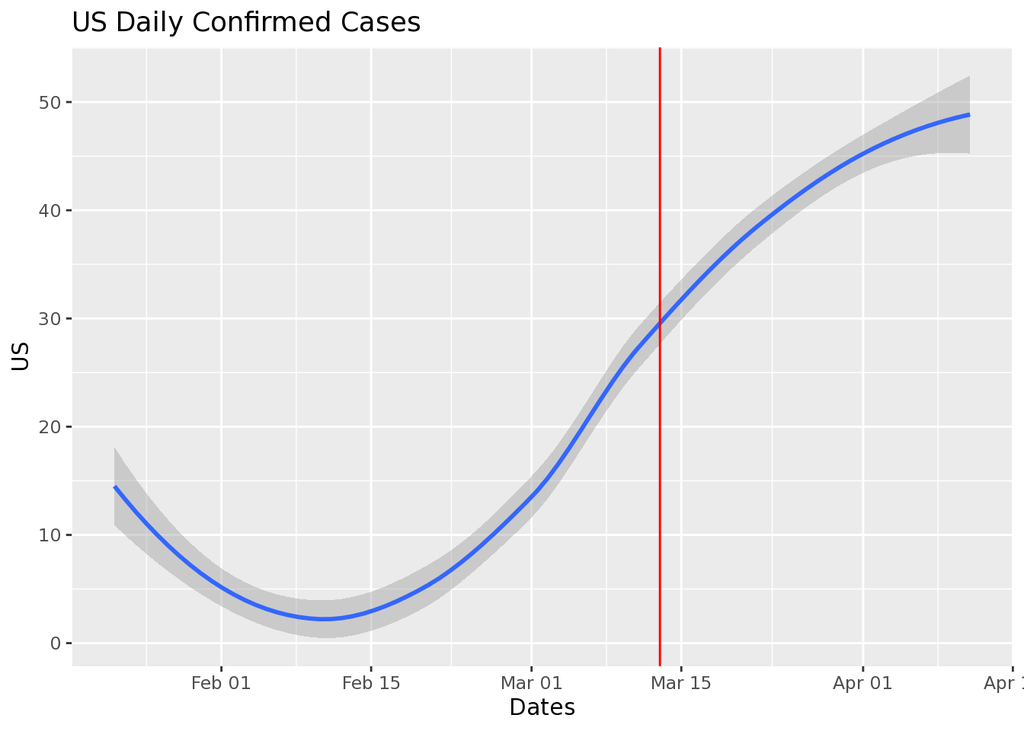

```r
CountriesConfirmed%>%
  ggplot(aes(x=Dates, y=US)) +
  geom_smooth() +
  ggtitle("US Daily Confirmed Cases") +
  geom_vline(xintercept = as.Date("2020-03-13"), color= "red") #date of social distancing/quarantine
```

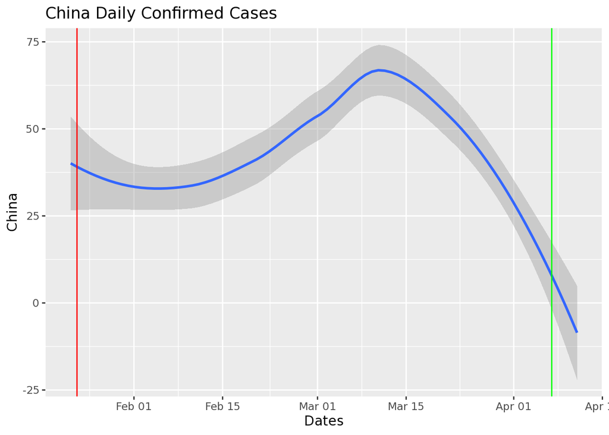

```r
CountriesConfirmed%>%
  ggplot(aes(x=Dates, y=China)) +
  geom_smooth() +
  ggtitle("China Daily Confirmed Cases") +
  geom_vline(xintercept = as.Date("2020-01-23"), color= "red")+ #strict quarantine date
  geom_vline(xintercept = as.Date("2020-04-07") , color= "green") #date of stage 1 reopening
```

Looking at the data above, China implemented a very strict quarantine on their entire country. Citizens were not allowed to leave their homes at all, and police delivered goods and necessary items to people’s homes. This strict protocol paid off for China, as their cases numbers dropped drastically while the country was able to sanitize itself of the virus. It is necessary to point out that the country was ahead of the United States for the timeline of the virus, however. China announced they were reopening to the public on April 7th, as shown by the green line.

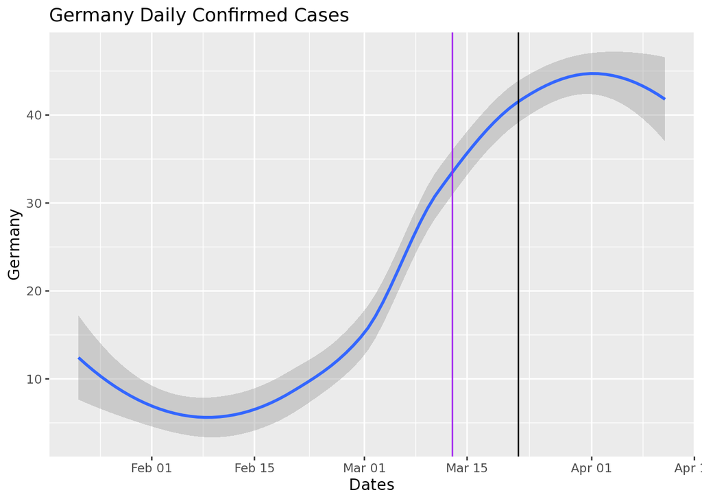

```r
CountriesConfirmed%>%
  ggplot(aes(x=Dates, y=Germany)) +
  geom_smooth() +
  ggtitle("Germany Daily Confirmed Cases") +
  geom_vline(xintercept = as.Date("2020-03-13"), color = "purple") + #protective stage date
  geom_vline(xintercept = as.Date("2020-03-22", color= "red")) #national curfew date
```

#### Deaths by Country

After looking at the new cases per day, I wanted to look at the deaths per country as this provides more insight into the country response. The United States has private healthcare while Germany has universal healthcare and China has a mixture of both.

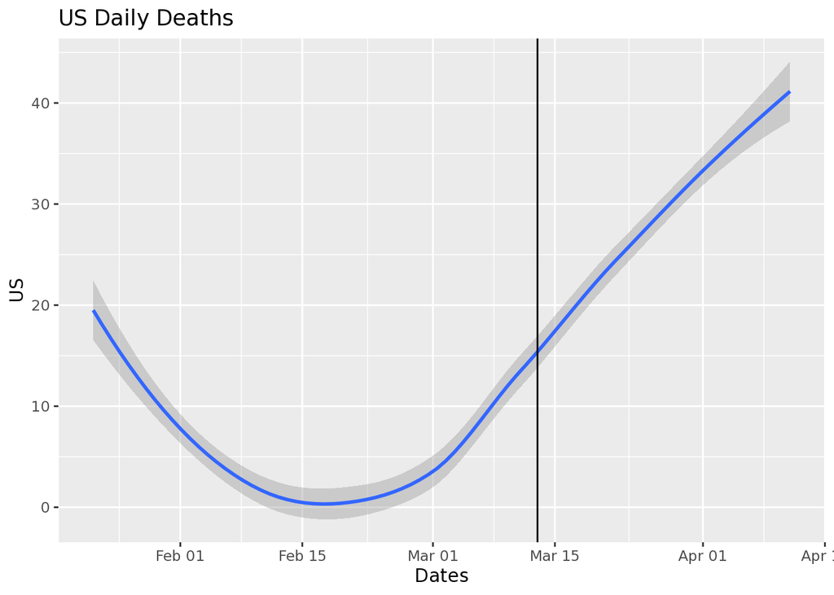

```r
CountriesDeaths%>%
   ggplot(aes(x=Dates, y=US)) +
  geom_smooth() +
  ggtitle("US Daily Deaths") +
  geom_vline(xintercept = as.Date("2020-03-13"), color= "black") #date of social distancing/quarantine
```

The line still consists of the social distancing date in the US. The deaths are continuing to skyrocket, which makes sense as of the incubation period and severity of the virus. Deaths are still continuing to rise. The United States has an entirely private healthcare system.

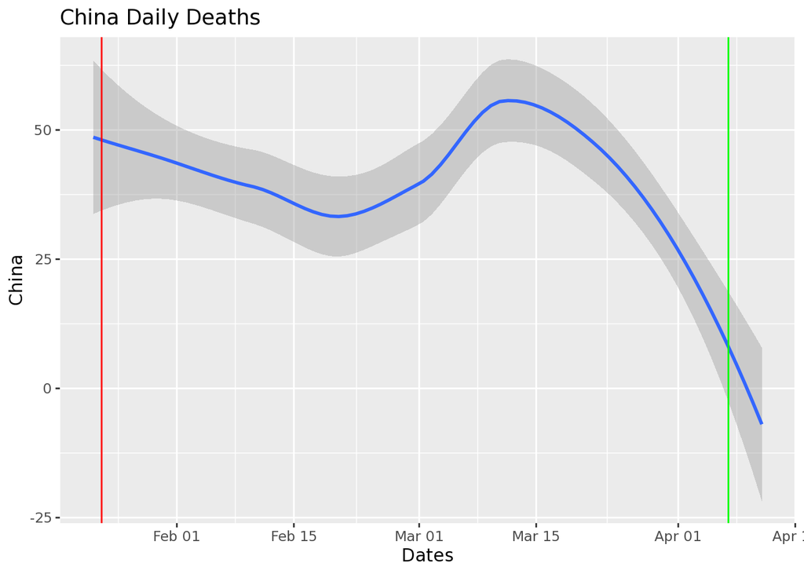

```r
CountriesDeaths%>%
ggplot(aes(x=Dates, y=China)) +
  geom_smooth() +
  ggtitle("China Daily Deaths") +
  geom_vline(xintercept = as.Date("2020-01-23"), color= "red")+ #strict quarantine date
  geom_vline(xintercept = as.Date("2020-04-07") , color= "green") #date of stage 1 reopening
```

China’s deaths were able to drastically drop following quarantine procedures. It is interesting to note that they have a mixture of public and private healthcare systems.

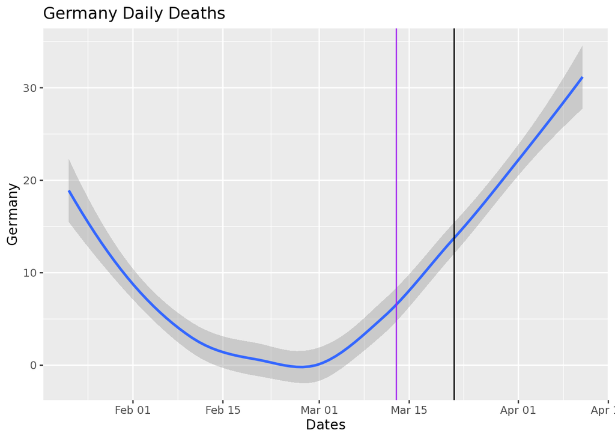

```r
CountriesDeaths%>%
  ggplot(aes(x=Dates, y=Germany)) +
  geom_smooth() +
  ggtitle("Germany Daily Deaths") +
  geom_vline(xintercept = as.Date("2020-03-13"), color = "purple") + #protective stage date
  geom_vline(xintercept = as.Date("2020-03-22", color= "red")) #national curfew date
```

Germany’s deaths are still skyrocketing, as of April 11th, which is to be expected as their country protocols were implemented later into the disease outbreak. Germany has a universal healthcare system.

### Conclusions

With regards to my research question, it appears as those China’s strict quarantine was the best at containing the spread of the virus, as of April 11th. There may be more data that comes out in the future, revealing true cases numbers from countries around the world, but right now it appears as though China is in the clear and is in the beginning stages of opening its society. For countries like Germany, and the US, measures were not implemented early enough and cases rose afterwards that could have been contained.

Althouh difficult, a strict quarantine that allows for a country to sanitize properly appears to be the best option in fighting the virus. These measures would be difficult in the United States due to the massive size, and enabling such protocols may go against personal rights established in laws.

When looking at new death totals per day, it appears as though China has the virus under control which supports the total confirmed case number data. Moving forward, I would love to look at the differences in healthcare among the countries more and see if that has any effect on the severity of disease burden across the three different countries.